# Klasyfikacja banknotów przy pomocy algorytmów opartych na drzewach decyzyjnych

## Wprowadzenie

Celem tego projektu jest porównanie działania algorytmów klasyfikacyjnych opartych na drzewach decyzyjnych, w tym celu wykorzystany zostanie zbiór danych zawierący informacje dotyczący prawdziwości banknotów. W czasie projektu zostanie zaprezentowany proces analizy zaczynający się od eksploracji oraz przygotowania danych, poprzez zbudowanie poprawnych i skutecznych modeli i kończący się jasnym zaprezentowaniem wyników.  
Projekt składa się z czterech części:

- Wprowadzenie
- Analiza wizualna oraz opisowa
- Budowa modeli
- Podsumowanie

## Analiza wizualna oraz opisowa

#### Opis danych

Dane pochodzą ze strony Machine Learning Repository:  
https://archive.ics.uci.edu/ml/datasets/banknote+authentication

Na stronie znajduje się następujący opis:  
: Dane uzyskano z obrazów pobranych z autentycznych i sfałszowanych próbek banknotów. Do digitalizacji wykorzystano kamerę przemysłową używaną zazwyczaj do kontroli druku. Ostateczne obrazy mają rozdzielczość 400x 400 pikseli. Dzięki obiektywowi obiektu oraz odległości od badanego obiektu uzyskano zdjęcia w skali szarości o rozdzielczości około 660 dpi. NTransformacja falkowa została użyta do wyodrębnienia cech z obrazów.

Informacje odnośnie atrybutów:

- wariancja obrazu
- przekrzywienie obrazu
- kurtoza obrazu
- entropia obrazu
- klasa obrazu

#### Eksploracja danych

```r
# Liczba obserwacji
nrow(data)
```

```
## [1] 1372
```

```r
# 10 pierwszych obserwacji
head(data, 10)
```

```
##    variance skewness curtosis  entropy class
## 1   3.62160   8.6661 -2.80730 -0.44699     0
## 2   4.54590   8.1674 -2.45860 -1.46210     0
## 3   3.86600  -2.6383  1.92420  0.10645     0
## 4   3.45660   9.5228 -4.01120 -3.59440     0
## 5   0.32924  -4.4552  4.57180 -0.98880     0
## 6   4.36840   9.6718 -3.96060 -3.16250     0
## 7   3.59120   3.0129  0.72888  0.56421     0
## 8   2.09220  -6.8100  8.46360 -0.60216     0
## 9   3.20320   5.7588 -0.75345 -0.61251     0
## 10  1.53560   9.1772 -2.27180 -0.73535     0
```

```r
# Podstawowe statystyki opisowe
summary(dplyr::select(data, -class))
```

```
##     variance          skewness          curtosis          entropy
##  Min.   :-7.0421   Min.   :-13.773   Min.   :-5.2861   Min.   :-8.5482
##  1st Qu.:-1.7730   1st Qu.: -1.708   1st Qu.:-1.5750   1st Qu.:-2.4135
##  Median : 0.4962   Median :  2.320   Median : 0.6166   Median :-0.5867
##  Mean   : 0.4337   Mean   :  1.922   Mean   : 1.3976   Mean   :-1.1917
##  3rd Qu.: 2.8215   3rd Qu.:  6.815   3rd Qu.: 3.1793   3rd Qu.: 0.3948
##  Max.   : 6.8248   Max.   : 12.952   Max.   :17.9274   Max.   : 2.4495
```

```r
# Rozkład obserwacji wzg. klas
table(data$class)
```

```
##
##   0   1
## 762 610
```

```r
# zmiana zmiennej class z integer na character
# data$class <- as.character(ifelse(data$class=="1", "Y", "N"))

#rozkLad obserwacji wzg. klas po zmianie
# table(data$class)
```

Jak widzimy, zbiór danych składa się z 1372 obserwacji, 762 obserwacje należą do klasy 0, która odpowiada za banknoty prawdziwe, natomiast pozostałe 610 reprezentuje fałszywki.

#### Przygotowanie danych

```r
# Sprawdzenie, czy któraś ze zmiennych jest zmienną quasi-stałą
caret::nearZeroVar(dplyr::select(data, -class), saveMetrics= TRUE)
```

```
##          freqRatio percentUnique zeroVar   nzv
## variance      1.25      97.52187   FALSE FALSE
## skewness      1.20      91.54519   FALSE FALSE
## curtosis      1.00      92.56560   FALSE FALSE
## entropy       1.00      84.25656   FALSE FALSE
```

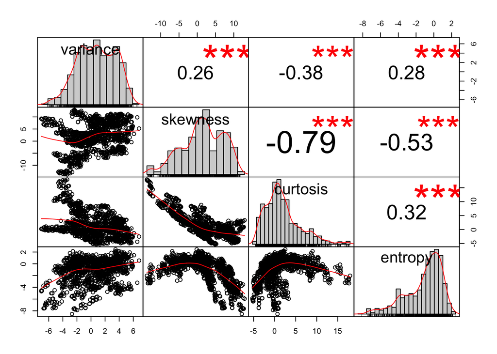

```r
# Identyfikacja silnie skorelowanych zmiennych
PerformanceAnalytics::chart.Correlation(dplyr::select(data, -class), histogram=TRUE)
```

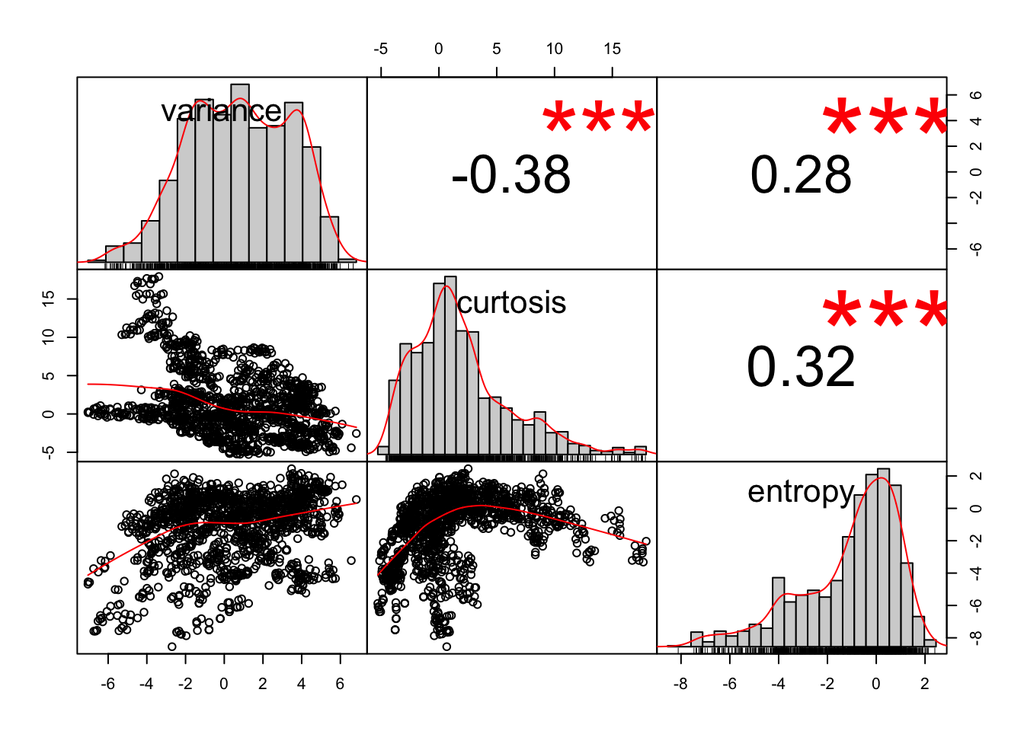

```r
# Usuwanie silnie skorelowanych zmiennych
data2 <- dplyr::select(data, -class)
cor_matrix <- cor(data2)
high_cor_var <- caret::findCorrelation(cor_matrix, cutoff = .75)
filter_data_cor <- data2[, -high_cor_var]

# Ponowne wyświetlenie korelacji pomiędzy zmiennymi
PerformanceAnalytics::chart.Correlation(filter_data_cor, histogram=TRUE)
```

```r
# Wyczyszczony zbiór danych
data <- cbind.data.frame(filter_data_cor, class = data$class)
head(data, 10)
```

```
##    variance curtosis  entropy class
## 1   3.62160 -2.80730 -0.44699     0
## 2   4.54590 -2.45860 -1.46210     0
## 3   3.86600  1.92420  0.10645     0
## 4   3.45660 -4.01120 -3.59440     0
## 5   0.32924  4.57180 -0.98880     0
## 6   4.36840 -3.96060 -3.16250     0
## 7   3.59120  0.72888  0.56421     0
## 8   2.09220  8.46360 -0.60216     0
## 9   3.20320 -0.75345 -0.61251     0
## 10  1.53560 -2.27180 -0.73535     0
```

#### Wizualizacja danych

```r
# Procentowy rozkład klas w zbiorze
print(percent_table)
```

```
##   class freq percent
## 1     0  762   55.54
## 2     1  610   44.46
```

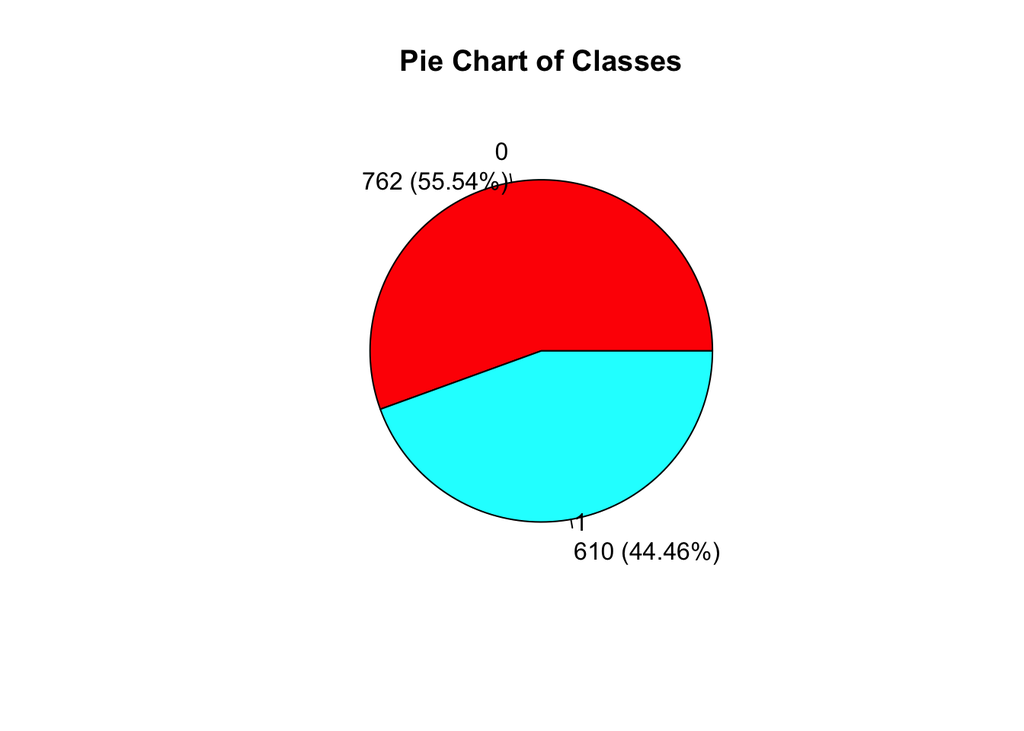

```r
# Wykres kołowy z rozkładem klas
pie(percent_chart$percent,
    labels=labels_chart,
    col=rainbow(length(percent_chart$class)),
    main="Pie Chart of Classes")
```

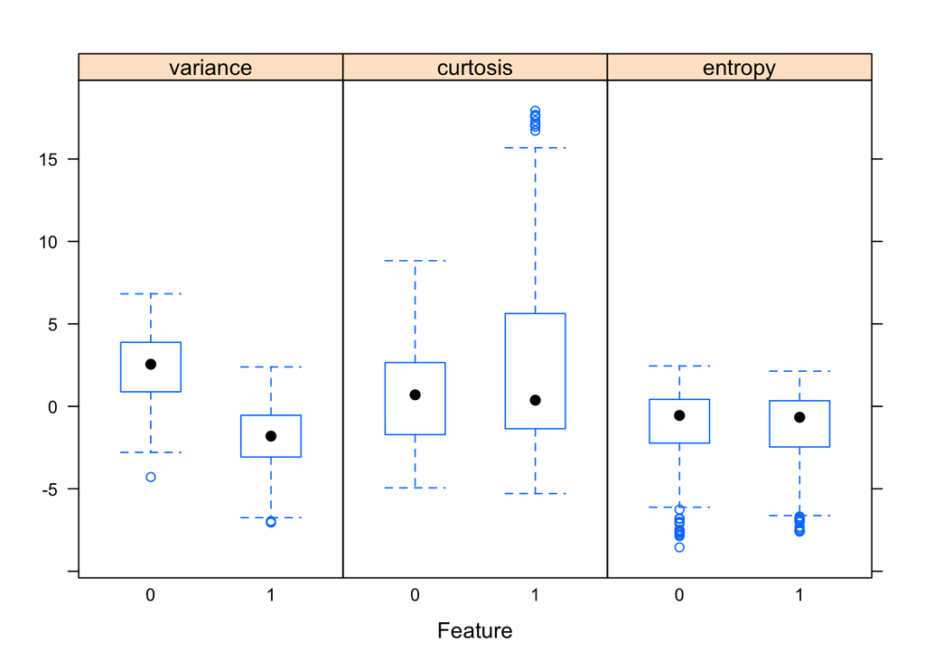

```r
# Rozkład zmiennych wzgledem klasy
caret::featurePlot(x=dplyr::select(data, -class), y=data$class %>% as.factor(), plot="box")
```

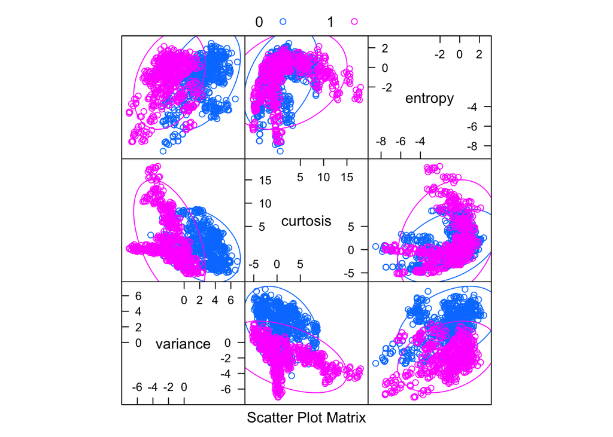

```r
# Klasy wzgledem zmiennych objasniajacych
caret::featurePlot(x=dplyr::select(data, -class), y=data$class %>% as.factor(), plot="ellipse", auto.key = list(columns = 2))
```

Wykres kołowy, pokazuje że mamy do czynienia ze zrównoważonym zbiorem danych. Wykresy pudełkowe względem klas pokazują, że zmienne, które mogą mieć największy wpływ na przynależność do danej klasy to wariancja oraz kurtoza. To samo potwierdza ostatni wykres, pokazujący interakcję między zmiennymi.

## Budowa modeli

W projekcie zostaną wykorzystane trzy metody klasyfikacji:

- Drzewo decyzyjne
- Random forest
- XGBoost

Każda z tych modeli zostanie przetestowany na zbiorze testowym,i za pomocą metryk takich jak accuracy oraz AUC zostanie wskazany najlepszy model.

#### Drzewo decyzyjne

```r
# Budowa modelu
dec_tree <- rpart::rpart(formula = class ~ . ,
                           data = train_set,
                           method = "class")

# Predykcje na zbiorze tstowym
dec_tree_pred_test <- predict(object = dec_tree,
                           newdata = test_set,
                           type = "class")

# Macierz pomyłek
caret::confusionMatrix(data = dec_tree_pred_test,
                       reference = test_set$class)
```

```
## Confusion Matrix and Statistics
##
##           Reference
## Prediction   0   1
##          0 211   7
##          1  27 167
##
##                Accuracy : 0.9175
##                  95% CI : (0.8866, 0.9422)
##     No Information Rate : 0.5777
##     P-Value [Acc > NIR] : < 2e-16
##
##                   Kappa : 0.8334
##
##  Mcnemar's Test P-Value : 0.00112
##
##             Sensitivity : 0.8866
##             Specificity : 0.9598
##          Pos Pred Value : 0.9679
##          Neg Pred Value : 0.8608
##              Prevalence : 0.5777
##          Detection Rate : 0.5121
##    Detection Prevalence : 0.5291
##       Balanced Accuracy : 0.9232
##
##        'Positive' Class : 0
##
```

```r
# Żeby policzyć AUC, wyniki przynależności do klas muszą być podane jako prawdopodobieństwa
dec_tree_pred_test_auc <- predict(object = dec_tree,
                           newdata = test_set,
                           type = "prob")
# AUC
Metrics::auc(test_set$class, dec_tree_pred_test_auc[,2])
```

```
## [1] 0.9446296
```

#### Random Forest

```r
# Model
rand_forest <- randomForest::randomForest(formula = class ~ .,
                                            data = train_set,
                                            mtry = 2,
                                            ntree = 250)

# Predykcje na zbiorze testowym
rand_forest_pred_test <- predict(object = rand_forest,
                            newdata = test_set[,-4],
                            type = "class")

# Macierz pomyłek
caret::confusionMatrix(data = rand_forest_pred_test,
                       reference = test_set$class %>% as.factor())
```

```
## Confusion Matrix and Statistics
##
##           Reference
## Prediction   0   1
##          0 230   1
##          1   8 173
##
##                Accuracy : 0.9782
##                  95% CI : (0.9589, 0.99)
##     No Information Rate : 0.5777
##     P-Value [Acc > NIR] : <2e-16
##
##                   Kappa : 0.9555
##
##  Mcnemar's Test P-Value : 0.0455
##
##             Sensitivity : 0.9664
##             Specificity : 0.9943
##          Pos Pred Value : 0.9957
##          Neg Pred Value : 0.9558
##              Prevalence : 0.5777
##          Detection Rate : 0.5583
##    Detection Prevalence : 0.5607
##       Balanced Accuracy : 0.9803
##
##        'Positive' Class : 0
##
```

```r
# Żeby policzyć AUC, wyniki przynależności do klas muszą być podane jako prawdopodobieństwa
rand_forest_pred_test_auc <- predict(object = rand_forest,
                           newdata = test_set,
                           type = "prob")
# AUC
Metrics::auc(test_set$class, rand_forest_pred_test_auc[,2])
```

```
## [1] 0.9946392
```

#### XGBoost

```r
# Przekształcenie danych do odpowiedniego inputu dla xgboosta
dm_treningowe <- xgb.DMatrix(data = data.matrix(train_set[,-4]), label = data.matrix(train_set[,4]))
dm_testowe <- xgb.DMatrix(data = data.matrix(test_set[,-4]), label = data.matrix(test_set[,4]))

# Model
xgb_model <- xgboost(data = dm_treningowe,
                     nround = 24,
                     eta = 0.2,
                     objectice = "binary:logistic",
                     verbose = 0)

# Predykcje
xgb_test_pred <- predict(xgb_model, dm_testowe)

# Macierz pomyłek
caret::confusionMatrix(data =  ifelse(xgb_test_pred > 0.5, 1, 0) %>% as.factor() ,
                       reference = test_set[,4])
```

```
## Confusion Matrix and Statistics
##
##           Reference
## Prediction   0   1
##          0 225   9
##          1  13 165
##
##                Accuracy : 0.9466
##                  95% CI : (0.9203, 0.9662)
##     No Information Rate : 0.5777
##     P-Value [Acc > NIR] : <2e-16
##
##                   Kappa : 0.8909
##
##  Mcnemar's Test P-Value : 0.5224
##
##             Sensitivity : 0.9454
##             Specificity : 0.9483
##          Pos Pred Value : 0.9615
##          Neg Pred Value : 0.9270
##              Prevalence : 0.5777
##          Detection Rate : 0.5461
##    Detection Prevalence : 0.5680
##       Balanced Accuracy : 0.9468
##
##        'Positive' Class : 0
##
```

```r
# Krzywa ROC i AUC
Metrics::auc(actual = test_set[,4], predicted = xgb_test_pred)
```

```
## [1] 0.9884937
```